### **Data 698: Project Proposal**

### **February 28, 2023**

$~$

### **Using predictive analytics to diagnose Polysystic Ovary Syndrome (PCOS)**

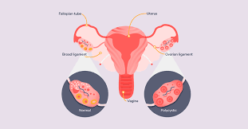

$~$

### **Introduction:**

Polycystic Ovary Syndrome (PCOS) is a reproductive hormonal imbalance disorder affecting women of reproductive age. The exact number of women affected by PCOS worldwide is difficult to determine as many cases go undiagnosed but according to the World Health Organization (WHO), there’s 3.4% of women who are affected [1]. Aside from the toll PCOS takes on your physical and emotional health, it causes problems in the ovaries, making it hard for women to have a healthy menstrual cycle leading to the development of cysts and infertility. It’s important to note that the prevalence of PCOS varies by region and ethnic group, with some studies suggesting higher rates of PCOS in certain populations [2]. This project will look into publicly available datasets that will allow us to create predictive models on test results to make a diagnosis.

$~$

### **Literature Review:**

- **Racial and ethnic differences in the metabolic response of polycystic ovary syndrome:**

This article speaks on the racial and ethnic disparities in the metabolic dysfunction suffered by PCOS and whether markers of metabolic function differ in nondiabetic Asian American (AS), African American (AA), Hispanic White (HW), compared to non-Hispanic White (NHW) women with PCOS.

- **A review: Brief insight into Polycystic Ovarian syndrome:**

This review highlights a brief overview of risk and pathophysiological treatment with drugs acting on ovulation, infertility plus clinical symptoms of PCOS.

- **DHEA, DHEAS and PCOS:**

This article examines the effect of excess adrenal precursor androgen (APA) production has on women with PCOS. The extra-adrenal factors, including obesity, insulin and glucose levels, and ovarian secretions, play a limited role in the increased APA production observed in PCOS.

$~$

#### **Objectives:**

This project hopes to be able to predict a PCOS diagnosis using logistic regression models.

$~$

#### **Methodology:**

Using R

$~$

### **References:**

- [1] Bulsara, J., Patel, P., Soni, A., & Acharya, S. (2021, February 10). A review: Brief insight into polycystic ovarian syndrome. Endocrine and Metabolic Science. Retrieved February 23, 2023, from https://www.sciencedirect.com/science/article/pii/S266639612100008X
- [2] Engmann, L., Jin, S., Sun, F., Legro, R. S., Polotsky, A. J., Hansen, K. R., Coutifaris, C., Diamond, M. P., Eisenberg, E., Zhang, H., Santoro, N., & Reproductive Medicine Network (2017). Racial and ethnic differences in the polycystic ovary syndrome metabolic phenotype. American journal of obstetrics and gynecology, 216(5), 493.e1–493.e13. https://doi.org/10.1016/j.ajog.2017.01.003